```python
import numpy as np
import pandas as pd
import matplotlib.pyplot as plt
import seaborn as sns
%matplotlib inline
import warnings
warnings.filterwarnings("ignore")
from sklearn.model_selection import train_test_split
from sklearn.neighbors import KNeighborsClassifier
from scipy.stats import zscore
from sklearn.metrics import classification_report
from sklearn.model_selection import GridSearchCV
```

# PART - A

```python
# 1.1 a
```

```python
path1 = 'Part1+-+Normal.csv'
data1 = pd.read_csv(path1)
data1
```

|  | P_incidence | P_tilt | L_angle | S_slope | P_radius | S_Degree | Class |
| --- | --- | --- | --- | --- | --- | --- | --- |
| 0 | 38.505273 | 16.964297 | 35.112814 | 21.540976 | 127.632875 | 7.986683 | Normal |
| 1 | 54.920858 | 18.968430 | 51.601455 | 35.952428 | 125.846646 | 2.001642 | Normal |
| 2 | 44.362490 | 8.945435 | 46.902096 | 35.417055 | 129.220682 | 4.994195 | Normal |
| 3 | 48.318931 | 17.452121 | 48.000000 | 30.866809 | 128.980308 | -0.910941 | Normal |
| 4 | 45.701789 | 10.659859 | 42.577846 | 35.041929 | 130.178314 | -3.388910 | Normal |
| ... | ... | ... | ... | ... | ... | ... | ... |
| 95 | 47.903565 | 13.616688 | 36.000000 | 34.286877 | 117.449062 | -4.245395 | Normal |
| 96 | 53.936748 | 20.721496 | 29.220534 | 33.215251 | 114.365845 | -0.421010 | Normal |
| 97 | 61.446597 | 22.694968 | 46.170347 | 38.751628 | 125.670725 | -2.707880 | Normal |
| 98 | 45.252792 | 8.693157 | 41.583126 | 36.559635 | 118.545842 | 0.214750 | Normal |
| 99 | 33.841641 | 5.073991 | 36.641233 | 28.767649 | 123.945244 | -0.199249 | Normal |

100 rows × 7 columns

```python
path2 = 'Part1+-+Type_H.csv'
data2 = pd.read_csv(path2)
data2
```

|  | P_incidence | P_tilt | L_angle | S_slope | P_radius | S_Degree | Class |
| --- | --- | --- | --- | --- | --- | --- | --- |
| 0 | 63.027817 | 22.552586 | 39.609117 | 40.475232 | 98.672917 | -0.254400 | Type_H |
| 1 | 39.056951 | 10.060991 | 25.015378 | 28.995960 | 114.405425 | 4.564259 | Type_H |
| 2 | 68.832021 | 22.218482 | 50.092194 | 46.613539 | 105.985135 | -3.530317 | Type_H |
| 3 | 69.297008 | 24.652878 | 44.311238 | 44.644130 | 101.868495 | 11.211523 | Type_H |
| 4 | 49.712859 | 9.652075 | 28.317406 | 40.060784 | 108.168725 | 7.918501 | Type_H |
| 5 | 40.250200 | 13.921907 | 25.124950 | 26.328293 | 130.327871 | 2.230652 | Type_H |
| 6 | 53.432928 | 15.864336 | 37.165934 | 37.568592 | 120.567523 | 5.988551 | Type_H |
| 7 | 45.366754 | 10.755611 | 29.038349 | 34.611142 | 117.270067 | -10.675871 | Type_H |
| 8 | 43.790190 | 13.533753 | 42.690814 | 30.256437 | 125.002893 | 13.289018 | Type_H |
| 9 | 36.686353 | 5.010884 | 41.948751 | 31.675469 | 84.241415 | 0.664437 | Type_H |
| 10 | 49.706610 | 13.040974 | 31.334500 | 36.665635 | 108.648265 | -7.825986 | Type_H |
| 11 | 31.232387 | 17.715819 | 15.500000 | 13.516568 | 120.055399 | 0.499751 | Type_H |
| 12 | 48.915551 | 19.964556 | 40.263794 | 28.950995 | 119.321358 | 8.028895 | Type_H |
| 13 | 53.572170 | 20.460828 | 33.100000 | 33.111342 | 110.966698 | 7.044803 | Type_H |
| 14 | 57.300227 | 24.188885 | 47.000000 | 33.111342 | 116.806587 | 5.766947 | Type_H |
| 15 | 44.318907 | 12.537992 | 36.098763 | 31.780915 | 124.115836 | 5.415825 | Type_H |
| 16 | 63.834982 | 20.362507 | 54.552434 | 43.472475 | 112.309491 | -0.622527 | Type_H |
| 17 | 31.276012 | 3.144669 | 32.562996 | 28.131342 | 129.011418 | 3.623020 | Type_H |
| 18 | 38.697912 | 13.444749 | 31.000000 | 25.253163 | 123.159251 | 1.429186 | Type_H |
| 19 | 41.729963 | 12.254074 | 30.122586 | 29.475889 | 116.585706 | -1.244402 | Type_H |
| 20 | 43.922840 | 14.177959 | 37.832547 | 29.744881 | 134.461016 | 6.451648 | Type_H |
| 21 | 54.919443 | 21.062332 | 42.200000 | 33.857110 | 125.212716 | 2.432561 | Type_H |
| 22 | 63.073611 | 24.413803 | 54.000000 | 38.659808 | 106.424329 | 15.779697 | Type_H |
| 23 | 45.540790 | 13.069598 | 30.298321 | 32.471192 | 117.980830 | -4.987130 | Type_H |
| 24 | 36.125683 | 22.758753 | 29.000000 | 13.366931 | 115.577116 | -3.237562 | Type_H |
| 25 | 54.124920 | 26.650489 | 35.329747 | 27.474432 | 121.447011 | 1.571205 | Type_H |
| 26 | 26.147921 | 10.759454 | 14.000000 | 15.388468 | 125.203296 | -10.093108 | Type_H |
| 27 | 43.580964 | 16.508884 | 47.000000 | 27.072080 | 109.271634 | 8.992816 | Type_H |
| 28 | 44.551012 | 21.931147 | 26.785916 | 22.619865 | 111.072920 | 2.652321 | Type_H |
| 29 | 66.879211 | 24.891999 | 49.278597 | 41.987212 | 113.477018 | -2.005892 | Type_H |
| 30 | 50.819268 | 15.402213 | 42.528939 | 35.417055 | 112.192804 | 10.869566 | Type_H |
| 31 | 46.390260 | 11.079047 | 32.136553 | 35.311213 | 98.774546 | 6.386832 | type_h |
| 32 | 44.936675 | 17.443838 | 27.780576 | 27.492837 | 117.980324 | 5.569620 | type_h |
| 33 | 38.663257 | 12.986441 | 40.000000 | 25.676816 | 124.914118 | 2.703008 | type_h |
| 34 | 59.595540 | 31.998244 | 46.560252 | 27.597296 | 119.330354 | 1.474286 | type_h |
| 35 | 31.484218 | 7.826221 | 24.284818 | 23.657997 | 113.833145 | 4.393080 | type_h |
| 36 | 32.090987 | 6.989378 | 35.998198 | 25.101609 | 132.264735 | 6.413428 | type_h |
| 37 | 35.703458 | 19.443253 | 20.700000 | 16.260205 | 137.540613 | -0.263490 | type_h |
| 38 | 55.843286 | 28.847448 | 47.690543 | 26.995838 | 123.311845 | 2.812427 | type_h |
| 39 | 52.419385 | 19.011561 | 35.872660 | 33.407825 | 116.559771 | 1.694705 | type_h |
| 40 | 35.492446 | 11.701672 | 15.590363 | 23.790774 | 106.938852 | -3.460358 | type_h |
| 41 | 46.442078 | 8.395036 | 29.037230 | 38.047043 | 115.481405 | 2.045476 | type_h |
| 42 | 53.854798 | 19.230643 | 32.779060 | 34.624155 | 121.670915 | 5.329843 | type_h |
| 43 | 66.285394 | 26.327845 | 47.500000 | 39.957549 | 121.219684 | -0.799624 | type_h |
| 44 | 56.030218 | 16.297915 | 62.275275 | 39.732303 | 114.023117 | -2.325684 | type_h |
| 45 | 50.912440 | 23.015169 | 47.000000 | 27.897271 | 117.422259 | -2.526702 | type_h |
| 46 | 48.332638 | 22.227784 | 36.181993 | 26.104854 | 117.384625 | 6.481709 | type_h |
| 47 | 41.352504 | 16.577364 | 30.706191 | 24.775141 | 113.266675 | -4.497958 | type_h |
| 48 | 40.557357 | 17.977784 | 34.000000 | 22.579573 | 121.046246 | -1.537383 | type_h |
| 49 | 41.767732 | 17.899402 | 20.030886 | 23.868330 | 118.363389 | 2.062963 | type_h |
| 50 | 55.285852 | 20.440118 | 34.000000 | 34.845733 | 115.877017 | 3.558372 | type_h |
| 51 | 74.433593 | 41.557331 | 27.700000 | 32.876262 | 107.949304 | 5.000089 | type_h |
| 52 | 50.209670 | 29.760122 | 36.104007 | 20.449548 | 128.292515 | 5.740614 | type_h |
| 53 | 30.149936 | 11.917445 | 34.000000 | 18.232491 | 112.684141 | 11.463223 | type_h |
| 54 | 41.171680 | 17.321206 | 33.469403 | 23.850474 | 116.377889 | -9.569250 | Type_H |
| 55 | 47.657730 | 13.277385 | 36.679985 | 34.380345 | 98.249781 | 6.273012 | Type_H |
| 56 | 43.349606 | 7.467469 | 28.065483 | 35.882137 | 112.776187 | 5.753277 | Type_H |
| 57 | 46.855781 | 15.351514 | 38.000000 | 31.504267 | 116.250917 | 1.662706 | Type_H |
| 58 | 43.203185 | 19.663146 | 35.000000 | 23.540039 | 124.846109 | -2.919076 | Type_H |
| 59 | 48.109236 | 14.930725 | 35.564683 | 33.178512 | 124.056452 | 7.947905 | Type_H |

```python
path3 = 'Part1+-+Type_S.csv'
data3 = pd.read_csv(path3)
data3
```

|  | P_incidence | P_tilt | L_angle | S_slope | P_radius | S_Degree | Class |
| --- | --- | --- | --- | --- | --- | --- | --- |
| 0 | 74.377678 | 32.053104 | 78.772013 | 42.324573 | 143.560690 | 56.125906 | Type_S |
| 1 | 89.680567 | 32.704435 | 83.130732 | 56.976132 | 129.955476 | 92.027277 | Type_S |
| 2 | 44.529051 | 9.433234 | 52.000000 | 35.095817 | 134.711772 | 29.106575 | Type_S |
| 3 | 77.690577 | 21.380645 | 64.429442 | 56.309932 | 114.818751 | 26.931841 | Type_S |
| 4 | 76.147212 | 21.936186 | 82.961502 | 54.211027 | 123.932010 | 10.431972 | Type_S |
| ... | ... | ... | ... | ... | ... | ... | ... |
| 145 | 80.111572 | 33.942432 | 85.101608 | 46.169139 | 125.593624 | 100.292107 | Type_S |
| 146 | 95.480229 | 46.550053 | 59.000000 | 48.930176 | 96.683903 | 77.283072 | Type_S |
| 147 | 74.094731 | 18.823727 | 76.032156 | 55.271004 | 128.405731 | 73.388216 | Type_S |
| 148 | 87.679087 | 20.365613 | 93.822416 | 67.313473 | 120.944829 | 76.730629 | Type_S |
| 149 | 48.259920 | 16.417462 | 36.329137 | 31.842457 | 94.882336 | 28.343799 | Type_S |

150 rows × 7 columns

```python
# 1.1b
```

```python
print(data1.shape)
print(data2.shape)
print(data3.shape)
```

```
(100, 7)
(60, 7)
(150, 7)
```

```python
print(data1.columns)
print(data2.columns)
print(data3.columns)
```

```
Index(['P_incidence', 'P_tilt', 'L_angle', 'S_slope', 'P_radius', 'S_Degree',
       'Class'],
      dtype='object')
Index(['P_incidence', 'P_tilt', 'L_angle', 'S_slope', 'P_radius', 'S_Degree',
       'Class'],
      dtype='object')
Index(['P_incidence', 'P_tilt', 'L_angle', 'S_slope', 'P_radius', 'S_Degree',
       'Class'],
      dtype='object')
```

```python
# 1.1c Comparing column names
# We can compare directly by reading above column names or by other methods like:-
```

```python
print(data1.columns.intersection(data2.columns).intersection(data3.columns))
```

```
Index(['P_incidence', 'P_tilt', 'L_angle', 'S_slope', 'P_radius', 'S_Degree',
       'Class'],
      dtype='object')
```

```python
print(data1.columns.tolist())
print(data2.columns.tolist())
print(data3.columns.tolist())
```

```
['P_incidence', 'P_tilt', 'L_angle', 'S_slope', 'P_radius', 'S_Degree', 'Class']
['P_incidence', 'P_tilt', 'L_angle', 'S_slope', 'P_radius', 'S_Degree', 'Class']
['P_incidence', 'P_tilt', 'L_angle', 'S_slope', 'P_radius', 'S_Degree', 'Class']
```

Observations:- All the three dataframes have same column names

```python
# 1.1d datatypes
```

```python
print(data1.dtypes)
print(data2.dtypes)
print(data3.dtypes)
```

```
P_incidence    float64
P_tilt         float64
L_angle        float64
S_slope        float64
P_radius       float64
S_Degree       float64
Class           object
dtype: object
P_incidence    float64
P_tilt         float64
L_angle        float64
S_slope        float64
P_radius       float64
S_Degree       float64
Class           object
dtype: object
P_incidence    float64
P_tilt         float64
L_angle        float64
S_slope        float64
P_radius       float64
S_Degree       float64
Class           object
dtype: object
```

```python
print(data1.info())
print(data2.info())
print(data3.info())
```

```
<class 'pandas.core.frame.DataFrame'>
RangeIndex: 100 entries, 0 to 99
Data columns (total 7 columns):
 #   Column       Non-Null Count  Dtype
---  ------       --------------  -----
 0   P_incidence  100 non-null    float64
 1   P_tilt       100 non-null    float64
 2   L_angle      100 non-null    float64
 3   S_slope      100 non-null    float64
 4   P_radius     100 non-null    float64
 5   S_Degree     100 non-null    float64
 6   Class        100 non-null    object
dtypes: float64(6), object(1)
memory usage: 5.6+ KB
None
<class 'pandas.core.frame.DataFrame'>
RangeIndex: 60 entries, 0 to 59
Data columns (total 7 columns):
 #   Column       Non-Null Count  Dtype
---  ------       --------------  -----
 0   P_incidence  60 non-null     float64
 1   P_tilt       60 non-null     float64
 2   L_angle      60 non-null     float64
 3   S_slope      60 non-null     float64
 4   P_radius     60 non-null     float64
 5   S_Degree     60 non-null     float64
 6   Class        60 non-null     object
dtypes: float64(6), object(1)
memory usage: 3.4+ KB
None
<class 'pandas.core.frame.DataFrame'>
RangeIndex: 150 entries, 0 to 149
Data columns (total 7 columns):
 #   Column       Non-Null Count  Dtype
---  ------       --------------  -----
 0   P_incidence  150 non-null    float64
 1   P_tilt       150 non-null    float64
 2   L_angle      150 non-null    float64
 3   S_slope      150 non-null    float64
 4   P_radius     150 non-null    float64
 5   S_Degree     150 non-null    float64
 6   Class        150 non-null    object
dtypes: float64(6), object(1)
memory usage: 8.3+ KB
None
```

```python
# 1.1e :- The variation in 'Class' feature for all 3 dataframes is that it is the only column having 'object' datatype.
# whereas remaining columns have a datatype of float.
```

```python
# 1.2 a
```

```python
data1 = data1.replace({'Class':{'Normal':'normal', 'Nrmal':'normal'}})
```

```python
data2 = data2.replace({'Class':{'Type_H':'type_h'}})
```

```python
data3 = data3.replace({'Class':{'Type_S':'type_s', 'tp_s':'type_s'}})
```

```python
# 1.2 b
```

```python
data_concat = pd.concat([data1, data2, data3], ignore_index=True, sort=False)
```

```python
data_concat
```

|  | P_incidence | P_tilt | L_angle | S_slope | P_radius | S_Degree | Class |
| --- | --- | --- | --- | --- | --- | --- | --- |
| 0 | 38.505273 | 16.964297 | 35.112814 | 21.540976 | 127.632875 | 7.986683 | normal |
| 1 | 54.920858 | 18.968430 | 51.601455 | 35.952428 | 125.846646 | 2.001642 | normal |
| 2 | 44.362490 | 8.945435 | 46.902096 | 35.417055 | 129.220682 | 4.994195 | normal |
| 3 | 48.318931 | 17.452121 | 48.000000 | 30.866809 | 128.980308 | -0.910941 | normal |
| 4 | 45.701789 | 10.659859 | 42.577846 | 35.041929 | 130.178314 | -3.388910 | normal |
| ... | ... | ... | ... | ... | ... | ... | ... |
| 305 | 80.111572 | 33.942432 | 85.101608 | 46.169139 | 125.593624 | 100.292107 | type_s |
| 306 | 95.480229 | 46.550053 | 59.000000 | 48.930176 | 96.683903 | 77.283072 | type_s |
| 307 | 74.094731 | 18.823727 | 76.032156 | 55.271004 | 128.405731 | 73.388216 | type_s |
| 308 | 87.679087 | 20.365613 | 93.822416 | 67.313473 | 120.944829 | 76.730629 | type_s |
| 309 | 48.259920 | 16.417462 | 36.329137 | 31.842457 | 94.882336 | 28.343799 | type_s |

310 rows × 7 columns

```python
# 1.2 c
```

```python
data_concat.sample(5, random_state=0)
```

|  | P_incidence | P_tilt | L_angle | S_slope | P_radius | S_Degree | Class |
| --- | --- | --- | --- | --- | --- | --- | --- |
| 300 | 63.364339 | 20.024621 | 67.498705 | 43.339718 | 130.999258 | 37.556706 | type_s |
| 145 | 50.912440 | 23.015169 | 47.000000 | 27.897271 | 117.422259 | -2.526702 | type_h |
| 302 | 76.314028 | 41.933683 | 93.284863 | 34.380345 | 132.267286 | 101.218783 | type_s |
| 222 | 80.074914 | 48.069531 | 52.403439 | 32.005383 | 110.709912 | 67.727316 | type_s |
| 52 | 42.517272 | 14.375671 | 25.323565 | 28.141601 | 128.905689 | 0.757020 | normal |

```python
# 1.2 d
```

```python
pd.DataFrame(data_concat.isna().mean().round(4)*100, columns=['Percentage of null values'])
```

|  | Percentage of null values |
| --- | --- |
| P_incidence | 0.0 |
| P_tilt | 0.0 |
| L_angle | 0.0 |
| S_slope | 0.0 |
| P_radius | 0.0 |
| S_Degree | 0.0 |
| Class | 0.0 |

There were no null values in any feature in the given dataframe Hence percentage of null values is 0%

```python
# 1.2 e
```

```python
data_concat.describe()
```

|  | P_incidence | P_tilt | L_angle | S_slope | P_radius | S_Degree |
| --- | --- | --- | --- | --- | --- | --- |
| count | 310.000000 | 310.000000 | 310.000000 | 310.000000 | 310.000000 | 310.000000 |
| mean | 60.496653 | 17.542822 | 51.930930 | 42.953831 | 117.920655 | 26.296694 |
| std | 17.236520 | 10.008330 | 18.554064 | 13.423102 | 13.317377 | 37.559027 |
| min | 26.147921 | -6.554948 | 14.000000 | 13.366931 | 70.082575 | -11.058179 |
| 25% | 46.430294 | 10.667069 | 37.000000 | 33.347122 | 110.709196 | 1.603727 |
| 50% | 58.691038 | 16.357689 | 49.562398 | 42.404912 | 118.268178 | 11.767934 |
| 75% | 72.877696 | 22.120395 | 63.000000 | 52.695888 | 125.467674 | 41.287352 |
| max | 129.834041 | 49.431864 | 125.742385 | 121.429566 | 163.071041 | 418.543082 |

```python
# 1.3a
```

```python
data_concat.corr()
```

|  | P_incidence | P_tilt | L_angle | S_slope | P_radius | S_Degree |
| --- | --- | --- | --- | --- | --- | --- |
| P_incidence | 1.000000 | 0.629199 | 0.717282 | 0.814960 | -0.247467 | 0.638743 |
| P_tilt | 0.629199 | 1.000000 | 0.432764 | 0.062345 | 0.032668 | 0.397862 |
| L_angle | 0.717282 | 0.432764 | 1.000000 | 0.598387 | -0.080344 | 0.533667 |
| S_slope | 0.814960 | 0.062345 | 0.598387 | 1.000000 | -0.342128 | 0.523557 |
| P_radius | -0.247467 | 0.032668 | -0.080344 | -0.342128 | 1.000000 | -0.026065 |
| S_Degree | 0.638743 | 0.397862 | 0.533667 | 0.523557 | -0.026065 | 1.000000 |

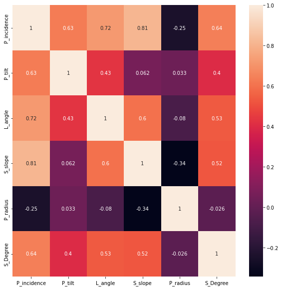

```python
fig, ax = plt.subplots(figsize=(10,10))
sns.heatmap(data_concat.corr(), annot=True);
```

```python
# 1.3b
```

Insights:-

The above indicates mixed correlation (Includes both positive and negative)

Not even one feature is perfectly correlated with other

P_incidence and S_slope shows more positively correlated and has highest correlation among the given data

P_radius shows neagative correlation with P_incidence, L_angle, S_slope and S_degree, it shows positive correlation only with P_tilt.

P_radius and S_slope are have least correlation.

P_incidence and S_slope have 81% correlation

P_incidence and L_angle have 72% correlation

P_incidence and S_Degree have 64% correlation

P_incidence and P_tilt have 63% correlation.

To conclude P_incidence has better correlation with other features whereas, P_radius has less correlation with other features.

```python
# 1.3 c
```

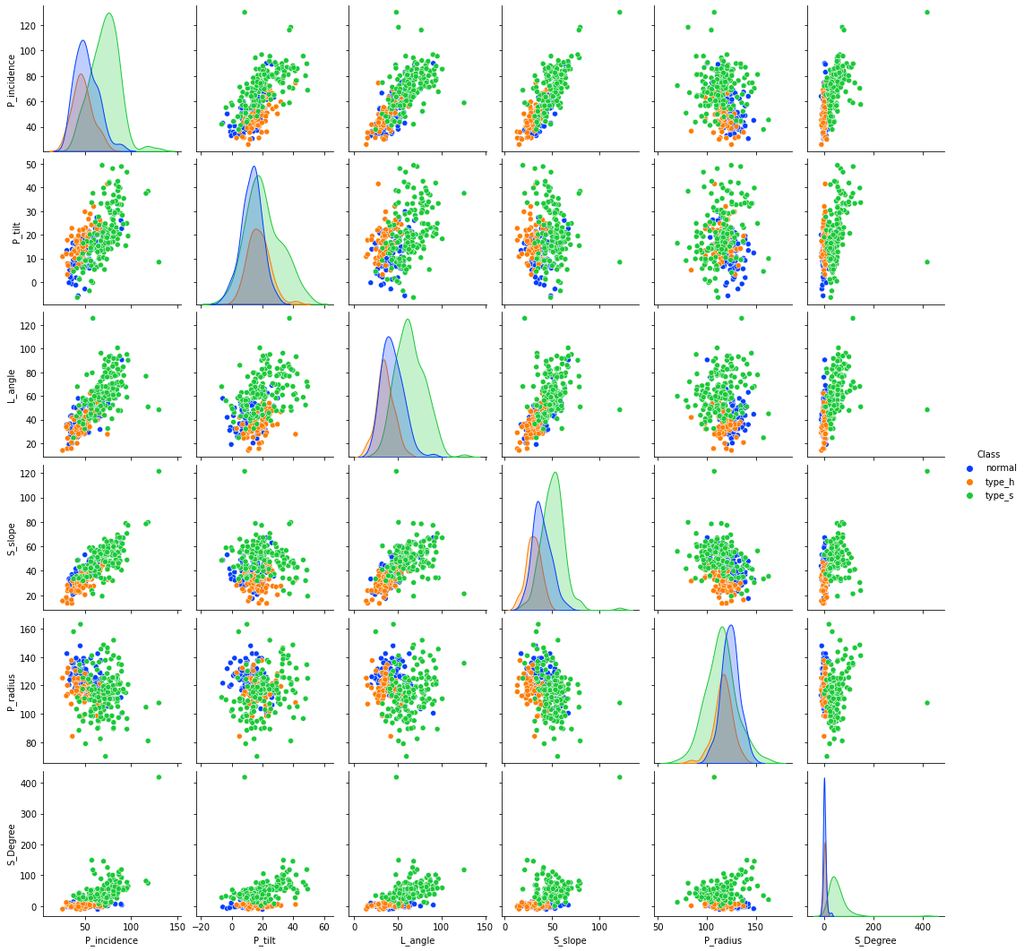

```python
sns.pairplot(data_concat, hue = 'Class', palette = 'bright');
```

Insights:-

-Along the diagonal we can see distribution of variable for three claases are not same.

-It is evident that type_s class is more compared to other two

-Overall, Scatter plots indicate that type_s is more among all three classes.

-For P_incidence, S_slope and L_angle distribution of (type_s > normal > type_h)

-For P_tilt :- normal > type_s > type_h

-For P_radius :- normal and type_s almost same but at peak normal is slightly greater than type_s and type_h is lower than both the classes.

-For S_Degree :- 'normal' has a sharp high peak followed by type_h and type_s respectively.

-Most of the features doesn't show a clear correlation.

-Overall, P_incidence shows positive correlation with S_slope, L_angle.

```python
# 1.3 d jointplot for ‘P_incidence’ and ‘S_slope’
```

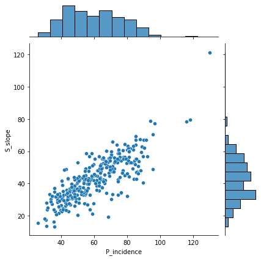

```python
sns.jointplot(data=data_concat, x='P_incidence', y='S_slope');
```

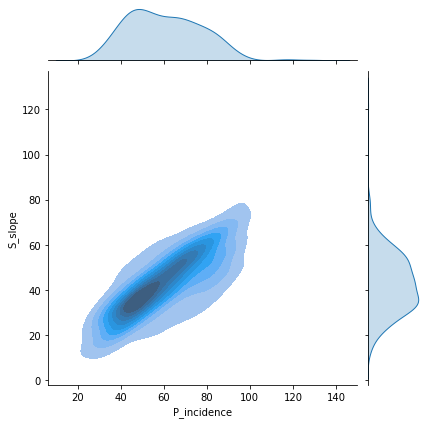

```python
sns.jointplot(data=data_concat, x='P_incidence', y='S_slope', kind = 'kde', fill =True);
```

Insights:-

Both s_slope and P_incidence are positively related to each other(As S_alope increases P_incidence also increases)

Highly correlated to each other

```python
# 1.3 e
```

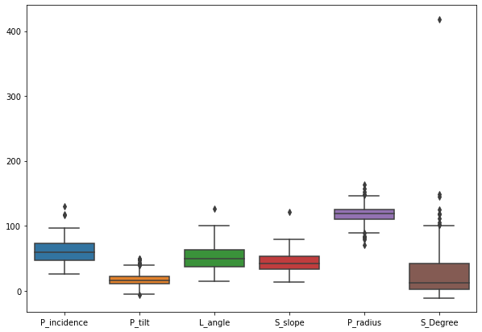

```python
plt.figure(figsize = (10,7))
sns.boxplot(data=data_concat);
```

Insights:-

S_Degree shows presence of outliers and is right-skewed as mean is towards left whisker

P_incidence, L_angle and S_slope also have ouliers

Inter_quartile range is large for S_Degree and least for P_tilt

```python
data_concat['Class'] = data_concat.Class.astype('category')
```

```python
#1.4 a
```

```python
x = data_concat.drop('Class', axis=1)
y = data_concat['Class']
```

```python
#1.4 b
```

```python
from sklearn.model_selection import train_test_split
x_train, x_test, y_train, y_test = train_test_split(x, y, test_size=0.2, random_state=1)
```

```python
x_train.head()
```

|  | P_incidence | P_tilt | L_angle | S_slope | P_radius | S_Degree |
| --- | --- | --- | --- | --- | --- | --- |
| 307 | 74.094731 | 18.823727 | 76.032156 | 55.271004 | 128.405731 | 73.388216 |
| 0 | 38.505273 | 16.964297 | 35.112814 | 21.540976 | 127.632875 | 7.986683 |
| 132 | 44.936675 | 17.443838 | 27.780576 | 27.492837 | 117.980324 | 5.569620 |
| 208 | 63.172987 | 6.330911 | 63.000000 | 56.842076 | 110.644021 | 42.608076 |
| 62 | 39.358705 | 7.011262 | 37.000000 | 32.347443 | 117.818760 | 1.904048 |

```python
# 1.4 b Checking whether the data is correctly divided or not
```

```python
print("{0:0.2f}% data is in training set".format((len(x_train)/len(data_concat.index)) * 100))
print("{0:0.2f}% data is in test set".format((len(x_test)/len(data_concat.index)) * 100))
```

```
80.00% data is in training set
20.00% data is in test set
```

```python
# 1.4c
```

```python
xscaled = x.apply(zscore)
xscaled.describe()
```

|  | P_incidence | P_tilt | L_angle | S_slope | P_radius | S_Degree |
| --- | --- | --- | --- | --- | --- | --- |
| count | 3.100000e+02 | 3.100000e+02 | 3.100000e+02 | 3.100000e+02 | 3.100000e+02 | 3.100000e+02 |
| mean | 1.042177e-16 | 2.096889e-16 | 1.980495e-16 | 2.829278e-17 | -5.071212e-16 | -1.277204e-16 |
| std | 1.001617e+00 | 1.001617e+00 | 1.001617e+00 | 1.001617e+00 | 1.001617e+00 | 1.001617e+00 |
| min | -1.996010e+00 | -2.411664e+00 | -2.047652e+00 | -2.207741e+00 | -3.597963e+00 | -9.961725e-01 |
| 25% | -8.173982e-01 | -6.881138e-01 | -8.060267e-01 | -7.168418e-01 | -5.423830e-01 | -6.585073e-01 |
| 50% | -1.049246e-01 | -1.186061e-01 | -1.278621e-01 | -4.095971e-02 | 2.613767e-02 | -3.874502e-01 |
| 75% | 7.194643e-01 | 4.581158e-01 | 5.975493e-01 | 7.269414e-01 | 5.676209e-01 | 3.997679e-01 |
| max | 4.029206e+00 | 3.191402e+00 | 3.984615e+00 | 5.855771e+00 | 3.395818e+00 | 1.046035e+01 |

```python
x_train, x_test, y_train, y_test = train_test_split(xscaled, y, test_size=0.20, random_state=1)
```

```python
KNN = KNeighborsClassifier(n_neighbors = 5, weights = 'distance')
```

```python
KNN.fit(x_train, y_train)
```

```
KNeighborsClassifier(weights='distance')
```

```python
predicted_labels = KNN.predict(x_test)
KNN.score(x_test, y_test)
```

```
0.7258064516129032
```

Indicates that 72.58 % predicted values are correct

```python
# 1.4d
```

```
Confusion Matrix
```

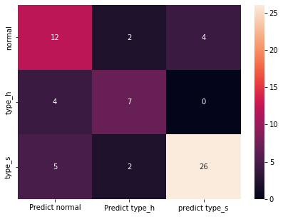

```python
from sklearn import metrics

print("Confusion Matrix")
cm=metrics.confusion_matrix(y_test, predicted_labels, labels=["normal", "type_h", "type_s"])

data_concat_cm = pd.DataFrame(cm, index = [i for i in ["normal","type_h", "type_s"]],
                  columns = [i for i in ["Predict normal","Predict type_h","predict type_s"]])
plt.figure(figsize = (7,5))
sns.heatmap(data_concat_cm, annot=True)
```

```python
print("classification  Matrix:\n",classification_report(y_test,predicted_labels))
```

```
classification  Matrix:
               precision    recall  f1-score   support

      normal       0.57      0.67      0.62        18
      type_h       0.64      0.64      0.64        11
      type_s       0.87      0.79      0.83        33

    accuracy                           0.73        62
   macro avg       0.69      0.70      0.69        62
weighted avg       0.74      0.73      0.73        62
```

- For type_s:-has maximum values f1_score is 83% recall is 79% precision is 87%
- For normal:- f1_score is 62% recall is 67% precision is 57%
- For type_h:- f1_score, precision and recall are same (64%)

```python
print('Accuracy on Training data:',KNN.score(x_train, y_train) )
print('Accuracy on Test data:',KNN.score(x_test, y_test) )
```

```
Accuracy on Training data: 1.0
Accuracy on Test data: 0.7258064516129032
```

```python
# 1.5a, b, c
```

```python
# Finding best k-value
```

```python
train_score=[]
test_score=[]
for k in range(1,51):
    KNN = KNeighborsClassifier(n_neighbors= k , metric = 'euclidean' )
    KNN.fit(x_train, y_train)
    train_score.append(KNN.score(x_train, y_train))
    test_score.append(KNN.score(x_test, y_test))
```

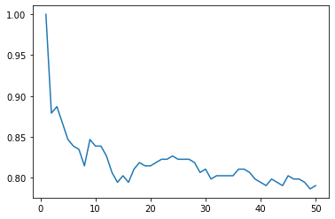

```python
plt.plot(range(1,51),train_score)
plt.show()
```

```python
# Parameters to improve performance are leaf_size, n_neighbors, p
```

```python
leaf_size = list(range(1,50))
n_neighbors = list(range(1,30))
p=[1,2]
#Convert to dictionary
hyperparameters = dict(leaf_size=leaf_size, n_neighbors=n_neighbors, p=p)
#Create new KNN object
knn_2 = KNeighborsClassifier()
#Use GridSearch
clf = GridSearchCV(knn_2, hyperparameters, cv=10)
#Fit the model
best_model = clf.fit(x,y)
#Print The value of best Hyperparameters
print('Best leaf_size:', best_model.best_estimator_.get_params()['leaf_size'])
print('Best p:', best_model.best_estimator_.get_params()['p'])
print('Best n_neighbors:', best_model.best_estimator_.get_params()['n_neighbors'])
```

```
Best leaf_size: 1
Best p: 2
Best n_neighbors: 25
```

Parameters that contributed to improvement are leaf_size:1, p:2, n_neighbors:25

```python
# 1.5(only n_neighbors is substituted)
```

```python
KNN = KNeighborsClassifier(n_neighbors = 25, weights = 'distance')
KNN.fit(x_train, y_train)
predicted_labels = KNN.predict(x_test)
KNN.score(x_test, y_test)
```

```
0.7419354838709677
```

```python
print("classification  Matrix:\n",classification_report(y_test,predicted_labels))
```

```
classification  Matrix:
               precision    recall  f1-score   support

      normal       0.57      0.67      0.62        18
      type_h       0.73      0.73      0.73        11
      type_s       0.87      0.79      0.83        33

    accuracy                           0.74        62
   macro avg       0.72      0.73      0.72        62
weighted avg       0.76      0.74      0.75        62
```

```python
# Parameters that contributed to improvement are leaf_size:1, p:2, n_neighbors:25
```

# PART - B

2.1a

```python
path = 'Part2+-+Data1.csv'
data1 = pd.read_csv(path)
data1
```

|  | ID | Age | CustomerSince | HighestSpend | ZipCode | HiddenScore | MonthlyAverageSpend | Level |
| --- | --- | --- | --- | --- | --- | --- | --- | --- |
| 0 | 1 | 25 | 1 | 49 | 91107 | 4 | 1.6 | 1 |
| 1 | 2 | 45 | 19 | 34 | 90089 | 3 | 1.5 | 1 |
| 2 | 3 | 39 | 15 | 11 | 94720 | 1 | 1.0 | 1 |
| 3 | 4 | 35 | 9 | 100 | 94112 | 1 | 2.7 | 2 |
| 4 | 5 | 35 | 8 | 45 | 91330 | 4 | 1.0 | 2 |
| ... | ... | ... | ... | ... | ... | ... | ... | ... |
| 4995 | 4996 | 29 | 3 | 40 | 92697 | 1 | 1.9 | 3 |
| 4996 | 4997 | 30 | 4 | 15 | 92037 | 4 | 0.4 | 1 |
| 4997 | 4998 | 63 | 39 | 24 | 93023 | 2 | 0.3 | 3 |
| 4998 | 4999 | 65 | 40 | 49 | 90034 | 3 | 0.5 | 2 |
| 4999 | 5000 | 28 | 4 | 83 | 92612 | 3 | 0.8 | 1 |

5000 rows × 8 columns

```python
path = 'Part2+-Data2.csv'
data2 = pd.read_csv(path)
data2
```

|  | ID | Mortgage | Security | FixedDepositAccount | InternetBanking | CreditCard | LoanOnCard |
| --- | --- | --- | --- | --- | --- | --- | --- |
| 0 | 1 | 0 | 1 | 0 | 0 | 0 | NaN |
| 1 | 2 | 0 | 1 | 0 | 0 | 0 | NaN |
| 2 | 3 | 0 | 0 | 0 | 0 | 0 | NaN |
| 3 | 4 | 0 | 0 | 0 | 0 | 0 | NaN |
| 4 | 5 | 0 | 0 | 0 | 0 | 1 | NaN |
| ... | ... | ... | ... | ... | ... | ... | ... |
| 4995 | 4996 | 0 | 0 | 0 | 1 | 0 | 0.0 |
| 4996 | 4997 | 85 | 0 | 0 | 1 | 0 | 0.0 |
| 4997 | 4998 | 0 | 0 | 0 | 0 | 0 | 0.0 |
| 4998 | 4999 | 0 | 0 | 0 | 1 | 0 | 0.0 |
| 4999 | 5000 | 0 | 0 | 0 | 1 | 1 | 0.0 |

5000 rows × 7 columns

2.1b Shape, datatypes and column names together

```python
print(data1.info())
print(data2.info())
```

```
<class 'pandas.core.frame.DataFrame'>
RangeIndex: 5000 entries, 0 to 4999
Data columns (total 8 columns):
 #   Column               Non-Null Count  Dtype
---  ------               --------------  -----
 0   ID                   5000 non-null   int64
 1   Age                  5000 non-null   int64
 2   CustomerSince        5000 non-null   int64
 3   HighestSpend         5000 non-null   int64
 4   ZipCode              5000 non-null   int64
 5   HiddenScore          5000 non-null   int64
 6   MonthlyAverageSpend  5000 non-null   float64
 7   Level                5000 non-null   int64
dtypes: float64(1), int64(7)
memory usage: 312.6 KB
None
<class 'pandas.core.frame.DataFrame'>
RangeIndex: 5000 entries, 0 to 4999
Data columns (total 7 columns):
 #   Column               Non-Null Count  Dtype
---  ------               --------------  -----
 0   ID                   5000 non-null   int64
 1   Mortgage             5000 non-null   int64
 2   Security             5000 non-null   int64
 3   FixedDepositAccount  5000 non-null   int64
 4   InternetBanking      5000 non-null   int64
 5   CreditCard           5000 non-null   int64
 6   LoanOnCard           4980 non-null   float64
dtypes: float64(1), int64(6)
memory usage: 273.6 KB
None
```

Shape of dataframe

```python
s1 = data1.shape
s2 = data2.shape
print(s1, s2)
```

```
(5000, 8) (5000, 7)
```

Datatypes

```python
t1 = data1.dtypes
t2 = data2.dtypes
print(t1)
print(t2)
```

```
ID                       int64
Age                      int64
CustomerSince            int64
HighestSpend             int64
ZipCode                  int64
HiddenScore              int64
MonthlyAverageSpend    float64
Level                    int64
dtype: object
ID                       int64
Mortgage                 int64
Security                 int64
FixedDepositAccount      int64
InternetBanking          int64
CreditCard               int64
LoanOnCard             float64
dtype: object
```

Column names

```python
names1 = data1.columns.values.tolist()
names2 = data2.columns.values.tolist()
print(names1)
print(names2)
```

```
['ID', 'Age', 'CustomerSince', 'HighestSpend', 'ZipCode', 'HiddenScore', 'MonthlyAverageSpend', 'Level']
['ID', 'Mortgage', 'Security', 'FixedDepositAccount', 'InternetBanking', 'CreditCard', 'LoanOnCard']
```

2.1c Merging dataframe

```python
newdata = pd.merge(data1,data2,on = 'ID', how='left')
newdata
```

|  | ID | Age | CustomerSince | HighestSpend | ZipCode | HiddenScore | MonthlyAverageSpend | Level | Mortgage | Security | FixedDepositAccount | InternetBanking | CreditCard | LoanOnCard |
| --- | --- | --- | --- | --- | --- | --- | --- | --- | --- | --- | --- | --- | --- | --- |
| 0 | 1 | 25 | 1 | 49 | 91107 | 4 | 1.6 | 1 | 0 | 1 | 0 | 0 | 0 | NaN |
| 1 | 2 | 45 | 19 | 34 | 90089 | 3 | 1.5 | 1 | 0 | 1 | 0 | 0 | 0 | NaN |
| 2 | 3 | 39 | 15 | 11 | 94720 | 1 | 1.0 | 1 | 0 | 0 | 0 | 0 | 0 | NaN |
| 3 | 4 | 35 | 9 | 100 | 94112 | 1 | 2.7 | 2 | 0 | 0 | 0 | 0 | 0 | NaN |
| 4 | 5 | 35 | 8 | 45 | 91330 | 4 | 1.0 | 2 | 0 | 0 | 0 | 0 | 1 | NaN |
| ... | ... | ... | ... | ... | ... | ... | ... | ... | ... | ... | ... | ... | ... | ... |
| 4995 | 4996 | 29 | 3 | 40 | 92697 | 1 | 1.9 | 3 | 0 | 0 | 0 | 1 | 0 | 0.0 |
| 4996 | 4997 | 30 | 4 | 15 | 92037 | 4 | 0.4 | 1 | 85 | 0 | 0 | 1 | 0 | 0.0 |
| 4997 | 4998 | 63 | 39 | 24 | 93023 | 2 | 0.3 | 3 | 0 | 0 | 0 | 0 | 0 | 0.0 |
| 4998 | 4999 | 65 | 40 | 49 | 90034 | 3 | 0.5 | 2 | 0 | 0 | 0 | 1 | 0 | 0.0 |
| 4999 | 5000 | 28 | 4 | 83 | 92612 | 3 | 0.8 | 1 | 0 | 0 | 0 | 1 | 1 | 0.0 |

5000 rows × 14 columns

```python
newdata.info()
```

```
<class 'pandas.core.frame.DataFrame'>
Int64Index: 5000 entries, 0 to 4999
Data columns (total 14 columns):
 #   Column               Non-Null Count  Dtype
---  ------               --------------  -----
 0   ID                   5000 non-null   int64
 1   Age                  5000 non-null   int64
 2   CustomerSince        5000 non-null   int64
 3   HighestSpend         5000 non-null   int64
 4   ZipCode              5000 non-null   int64
 5   HiddenScore          5000 non-null   int64
 6   MonthlyAverageSpend  5000 non-null   float64
 7   Level                5000 non-null   int64
 8   Mortgage             5000 non-null   int64
 9   Security             5000 non-null   int64
 10  FixedDepositAccount  5000 non-null   int64
 11  InternetBanking      5000 non-null   int64
 12  CreditCard           5000 non-null   int64
 13  LoanOnCard           4980 non-null   float64
dtypes: float64(2), int64(12)
memory usage: 585.9 KB
```

2.1D Changing datatype:-

```python
newdata[['CreditCard','InternetBanking','FixedDepositAccount','Security', 'Level','HiddenScore']] = newdata[['CreditCard','InternetBanking','FixedDepositAccount','Security', 'Level','HiddenScore']].astype(object)
newdata.info()
```

```
<class 'pandas.core.frame.DataFrame'>
Int64Index: 5000 entries, 0 to 4999
Data columns (total 14 columns):
 #   Column               Non-Null Count  Dtype
---  ------               --------------  -----
 0   ID                   5000 non-null   int64
 1   Age                  5000 non-null   int64
 2   CustomerSince        5000 non-null   int64
 3   HighestSpend         5000 non-null   int64
 4   ZipCode              5000 non-null   int64
 5   HiddenScore          5000 non-null   object
 6   MonthlyAverageSpend  5000 non-null   float64
 7   Level                5000 non-null   object
 8   Mortgage             5000 non-null   int64
 9   Security             5000 non-null   object
 10  FixedDepositAccount  5000 non-null   object
 11  InternetBanking      5000 non-null   object
 12  CreditCard           5000 non-null   object
 13  LoanOnCard           4980 non-null   float64
dtypes: float64(2), int64(6), object(6)
memory usage: 585.9+ KB
```

Datatype of features having binary values has been changed to object

2.2a

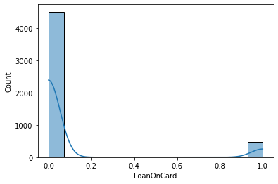

```python
sns.histplot(newdata['LoanOnCard'],kde=True);
```

Insights:-

The above plot indicates that initially almost all (or most) of the customers did not take or have loan on card

In between two extremes almost none of the customers took loan on their cards(we can also say that it looks like asymptomatic as the curve touches the axis)

At the other extreme means right side of the plot indicates that very few customers have taken loan on cards

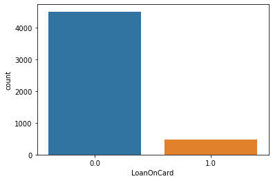

```python
sns.countplot(newdata['LoanOnCard']);
```

Most of the people doesn't have LoanOnCard. Very few people have LoanOnCard

2.2b

```python
percent_missing = newdata.isnull().sum() * 100 / len(newdata)
```

```python
percent_missing
```

```
ID                     0.0
Age                    0.0
CustomerSince          0.0
HighestSpend           0.0
ZipCode                0.0
HiddenScore            0.0
MonthlyAverageSpend    0.0
Level                  0.0
Mortgage               0.0
Security               0.0
FixedDepositAccount    0.0
InternetBanking        0.0
CreditCard             0.0
LoanOnCard             0.4
dtype: float64
```

Only LoanOnCard have missing values of 0.4%

```python
#We have very less missing value so we will drop the missing records.
newdata.dropna(axis=0,inplace=True)
```

```python
newdata.isnull().sum()
```

```
ID                     0
Age                    0
CustomerSince          0
HighestSpend           0
ZipCode                0
HiddenScore            0
MonthlyAverageSpend    0
Level                  0
Mortgage               0
Security               0
FixedDepositAccount    0
InternetBanking        0
CreditCard             0
LoanOnCard             0
dtype: int64
```

All the missing records are dropped

```python
pd.DataFrame( newdata.isnull().sum(), columns= ['Number of missing values'])
```

|  | Number of missing values |
| --- | --- |
| ID | 0 |
| Age | 0 |
| CustomerSince | 0 |
| HighestSpend | 0 |
| ZipCode | 0 |
| HiddenScore | 0 |
| MonthlyAverageSpend | 0 |
| Level | 0 |
| Mortgage | 0 |
| Security | 0 |
| FixedDepositAccount | 0 |
| InternetBanking | 0 |
| CreditCard | 0 |
| LoanOnCard | 0 |

```python
newdata.isnull().values.any()
```

```
False
```

Indicates that there were no missing values.

2.2c Check for unexpected values in each categorical variable and impute with best suitable value.

```python
# Categorical variables having binary values
```

```python
newdata.groupby(['Security', 'FixedDepositAccount', 'CreditCard', 'InternetBanking']).count()
```

| Security | FixedDepositAccount | CreditCard | InternetBanking | Age | CustomerSince | HighestSpend | ZipCode | HiddenScore | MonthlyAverageSpend | Level | Mortgage | LoanOnCard |
| --- | --- | --- | --- | --- | --- | --- | --- | --- | --- | --- | --- | --- |
| 0 | 0 | 0 | 0 | 1279 | 1279 | 1279 | 1279 | 1279 | 1279 | 1279 | 1279 | 1279 |
|  |  |  | 1 | 1845 | 1845 | 1845 | 1845 | 1845 | 1845 | 1845 | 1845 | 1845 |
|  |  | 1 | 0 | 524 | 524 | 524 | 524 | 524 | 524 | 524 | 524 | 524 |
|  |  |  | 1 | 657 | 657 | 657 | 657 | 657 | 657 | 657 | 657 | 657 |
|  | 1 | 0 | 1 | 13 | 13 | 13 | 13 | 13 | 13 | 13 | 13 | 13 |
|  |  | 1 | 0 | 4 | 4 | 4 | 4 | 4 | 4 | 4 | 4 | 4 |
|  |  |  | 1 | 138 | 138 | 138 | 138 | 138 | 138 | 138 | 138 | 138 |
| 1 | 0 | 0 | 0 | 139 | 139 | 139 | 139 | 139 | 139 | 139 | 139 | 139 |
|  |  |  | 1 | 189 | 189 | 189 | 189 | 189 | 189 | 189 | 189 | 189 |
|  |  | 1 | 0 | 45 | 45 | 45 | 45 | 45 | 45 | 45 | 45 | 45 |
|  | 1 | 0 | 0 | 3 | 3 | 3 | 3 | 3 | 3 | 3 | 3 | 3 |
|  |  |  | 1 | 46 | 46 | 46 | 46 | 46 | 46 | 46 | 46 | 46 |
|  |  | 1 | 0 | 12 | 12 | 12 | 12 | 12 | 12 | 12 | 12 | 12 |
|  |  |  | 1 | 86 | 86 | 86 | 86 | 86 | 86 | 86 | 86 | 86 |

```python
# Categorical variables having values otherthan binary values
```

```python
newdata.groupby(['HiddenScore', 'Level']).count()
```

| HiddenScore | Level | ID | Age | CustomerSince | HighestSpend | ZipCode | MonthlyAverageSpend | Mortgage | Security | FixedDepositAccount | InternetBanking | CreditCard | LoanOnCard |
| --- | --- | --- | --- | --- | --- | --- | --- | --- | --- | --- | --- | --- | --- |
| 1 | 1 | 677 | 677 | 677 | 677 | 677 | 677 | 677 | 677 | 677 | 677 | 677 | 677 |
|  | 2 | 324 | 324 | 324 | 324 | 324 | 324 | 324 | 324 | 324 | 324 | 324 | 324 |
|  | 3 | 465 | 465 | 465 | 465 | 465 | 465 | 465 | 465 | 465 | 465 | 465 | 465 |
| 2 | 1 | 655 | 655 | 655 | 655 | 655 | 655 | 655 | 655 | 655 | 655 | 655 | 655 |
|  | 2 | 264 | 264 | 264 | 264 | 264 | 264 | 264 | 264 | 264 | 264 | 264 | 264 |
|  | 3 | 374 | 374 | 374 | 374 | 374 | 374 | 374 | 374 | 374 | 374 | 374 | 374 |
| 3 | 1 | 347 | 347 | 347 | 347 | 347 | 347 | 347 | 347 | 347 | 347 | 347 | 347 |
|  | 2 | 381 | 381 | 381 | 381 | 381 | 381 | 381 | 381 | 381 | 381 | 381 | 381 |
|  | 3 | 278 | 278 | 278 | 278 | 278 | 278 | 278 | 278 | 278 | 278 | 278 | 278 |
| 4 | 1 | 410 | 410 | 410 | 410 | 410 | 410 | 410 | 410 | 410 | 410 | 410 | 410 |
|  | 2 | 426 | 426 | 426 | 426 | 426 | 426 | 426 | 426 | 426 | 426 | 426 | 426 |
|  | 3 | 379 | 379 | 379 | 379 | 379 | 379 | 379 | 379 | 379 | 379 | 379 | 379 |

Indicates that variables like 'Security', 'FixedDepositAccount', 'CreditCard', 'InternetBanking' have binary values(0 and 1). But 'Level' has (1,2,3) and 'HiddenScore has (1,2,3,4).

As ID is not useful we can drop that column

```python
newdata.drop('ID',axis=1,inplace=True)
```

```python
newdata.describe()
```

|  | Age | CustomerSince | HighestSpend | ZipCode | MonthlyAverageSpend | Mortgage | LoanOnCard |
| --- | --- | --- | --- | --- | --- | --- | --- |
| count | 4980.000000 | 4980.000000 | 4980.00000 | 4980.000000 | 4980.000000 | 4980.000000 | 4980.000000 |
| mean | 45.352610 | 20.117671 | 73.85241 | 93152.420482 | 1.939536 | 56.589759 | 0.096386 |
| std | 11.464212 | 11.468716 | 46.07009 | 2123.660073 | 1.750006 | 101.836758 | 0.295149 |
| min | 23.000000 | -3.000000 | 8.00000 | 9307.000000 | 0.000000 | 0.000000 | 0.000000 |
| 25% | 35.000000 | 10.000000 | 39.00000 | 91911.000000 | 0.700000 | 0.000000 | 0.000000 |
| 50% | 45.000000 | 20.000000 | 64.00000 | 93407.000000 | 1.500000 | 0.000000 | 0.000000 |
| 75% | 55.000000 | 30.000000 | 98.00000 | 94608.000000 | 2.525000 | 101.000000 | 0.000000 |
| max | 67.000000 | 43.000000 | 224.00000 | 96651.000000 | 10.000000 | 635.000000 | 1.000000 |

```python
# Changing LoanOnCard to category before splitting
```

```python
newdata['LoanOnCard'] = newdata.LoanOnCard.astype('category')
```

2.3a Splitting data

```python
x = newdata.drop('LoanOnCard', axis=1)
y = newdata['LoanOnCard']
```

2.3b

```python
from sklearn.model_selection import train_test_split
x_train, x_test, y_train, y_test = train_test_split(x, y, test_size=0.25, random_state=1)
```

```python
x_train
```

|  | Age | CustomerSince | HighestSpend | ZipCode | HiddenScore | MonthlyAverageSpend | Level | Mortgage | Security | FixedDepositAccount | InternetBanking | CreditCard |
| --- | --- | --- | --- | --- | --- | --- | --- | --- | --- | --- | --- | --- |
| 3980 | 46 | 22 | 89 | 92866 | 4 | 1.4 | 2 | 0 | 0 | 0 | 1 | 0 |
| 4489 | 39 | 13 | 21 | 95518 | 3 | 0.2 | 2 | 0 | 0 | 0 | 1 | 0 |
| 4414 | 33 | 8 | 178 | 94720 | 3 | 8.5 | 1 | 0 | 1 | 1 | 1 | 0 |
| 877 | 35 | 11 | 59 | 95123 | 4 | 0.1 | 2 | 0 | 0 | 0 | 0 | 0 |
| 4390 | 52 | 26 | 62 | 95134 | 4 | 2.8 | 2 | 0 | 0 | 0 | 1 | 0 |
| ... | ... | ... | ... | ... | ... | ... | ... | ... | ... | ... | ... | ... |
| 2915 | 34 | 9 | 133 | 92110 | 1 | 3.8 | 1 | 0 | 0 | 0 | 1 | 0 |
| 2783 | 53 | 26 | 25 | 92123 | 2 | 1.0 | 2 | 0 | 0 | 1 | 1 | 1 |
| 925 | 42 | 18 | 31 | 94720 | 1 | 0.3 | 3 | 0 | 0 | 0 | 0 | 1 |
| 4000 | 62 | 37 | 93 | 93003 | 3 | 3.0 | 3 | 0 | 0 | 1 | 1 | 1 |
| 255 | 66 | 40 | 42 | 92103 | 2 | 0.7 | 3 | 138 | 0 | 0 | 0 | 1 |

3735 rows × 12 columns

2.3b Checking split data

```python
print("{0:0.2f}% data is in training set".format((len(x_train)/len(newdata.index)) * 100))
print("{0:0.2f}% data is in test set".format((len(x_test)/len(newdata.index)) * 100))
```

```
75.00% data is in training set
25.00% data is in test set
```

2.3c Logistic Regression

```python
from sklearn import metrics

from sklearn.linear_model import LogisticRegression


model = LogisticRegression(solver="liblinear")
model.fit(x_train, y_train)
y_predict = model.predict(x_test)


coef_df = pd.DataFrame(model.coef_)
coef_df['intercept'] = model.intercept_
print(coef_df)
```

```
         0         1         2         3         4         5         6  \
0  0.00762  0.005455  0.036192 -0.000071  0.013803  0.007364  0.016328

         7         8         9        10        11  intercept
0  0.00064  0.000826  0.004467 -0.000063  0.000403   -0.00005
```

```python
model_score = model.score(x_test, y_test)
print(model_score)
```

```
0.9060240963855422
```

90.6 % indicates that it is a good model

```python
# 2.3d
```

```python
print('Accuracy on Training data:',model.score(x_train, y_train) )
print('Accuracy on Test data:',model.score(x_test, y_test) )
```

```
Accuracy on Training data: 0.908433734939759
Accuracy on Test data: 0.9060240963855422
```

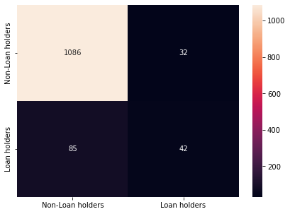

```python
cm=metrics.confusion_matrix(y_test, y_predict, labels=[0, 1])

df_cm = pd.DataFrame(cm, index = [i for i in ["Non-Loan holders","Loan holders"]],
                  columns = [i for i in ["Non-Loan holders","Loan holders"]])
plt.figure(figsize = (7,5))
sns.heatmap(df_cm, annot=True, fmt='g')
plt.show()
```

```python
# Precision, Recall, f1-score
```

```python
print("Classification Report")
print(metrics.classification_report(y_test, y_predict, labels=[0, 1]))
```

```
Classification Report
              precision    recall  f1-score   support

           0       0.93      0.97      0.95      1118
           1       0.57      0.33      0.42       127

    accuracy                           0.91      1245
   macro avg       0.75      0.65      0.68      1245
weighted avg       0.89      0.91      0.89      1245
```

Overall accuracy, precision, recall, f1-score for Non-Loan holders is good

```python
# 2.3e
```

```python
pip install imblearn
```

```python
from imblearn import under_sampling, over_sampling
from imblearn.over_sampling import SMOTE
```

```python
from imblearn.over_sampling import RandomOverSampler
from imblearn.over_sampling import SMOTENC
from imblearn.over_sampling import SMOTE
```

```python
smote_nc=SMOTENC(categorical_features=[1,3,5],random_state=42)
x_s,y_s=smote_nc.fit_resample(x,y)
```

```python
print('Before sampling:')
print(y.value_counts())
```

```
Before sampling:
0.0    4500
1.0     480
Name: LoanOnCard, dtype: int64
```

```python
print('After sampling:')
print(y_s.value_counts())
```

```
After sampling:
0.0    4500
1.0    4500
Name: LoanOnCard, dtype: int64
```

```python
# 2.3 f, g
```

```python
x_train, x_test, y_train, y_test = train_test_split(x_s, y_s, test_size=0.25, random_state=10)
```

```python
logit = LogisticRegression()
logit.fit(x_train, y_train)
logit_pred = logit.predict(x_test)

print('Accuracy on Training data:',logit.score(x_train, y_train) )
print('Accuracy on Test data:',logit.score(x_test, y_test) )
```

```
Accuracy on Training data: 0.8832592592592593
Accuracy on Test data: 0.8831111111111111
```

Accuracy is reduced after sampling for both train and test data.

```python
from sklearn.metrics import accuracy_score, confusion_matrix
from sklearn.linear_model import LogisticRegression
from sklearn.naive_bayes import GaussianNB
from sklearn.svm import SVC
```

[figure not shown]

```python
cm = confusion_matrix(y_test, logit_pred, labels=[0, 1])

df_cm = pd.DataFrame(cm, index = [i for i in ["Non-Loan holders","Loan holders"]],
                  columns = [i for i in ["Non-Loan holders","Loan holders"]])
plt.figure(figsize = (7,5))
sns.heatmap(df_cm, annot=True ,fmt='g')
plt.show()
```

Here data is balanced

```python
print("classification  Matrix:\n",classification_report(y_test,logit_pred))
```

[output not shown]

2.3 f Training on balanced data

```python
x_train, x_test, y_train, y_test = train_test_split(x, y, test_size=0.25, random_state=42)
```

```python
smote_nc=SMOTENC(categorical_features=[1,3,5],random_state=30)
x_train_res, y_train_res = smote_nc.fit_resample(x_train, y_train)
```

2.3 g

```python
logit = LogisticRegression()
logit.fit(x_train_res, y_train_res)
logit_pred = logit.predict(x_test)

print('Accuracy on Training data:',logit.score(x_train, y_train) )
print('Accuracy on Test data:',logit.score(x_test, y_test) )
```

```
Accuracy on Training data: 0.877376171352075
Accuracy on Test data: 0.8730923694779117
```

[figure not shown]

```python
cm = confusion_matrix(y_test, logit_pred, labels=[0, 1])

df_cm = pd.DataFrame(cm, index = [i for i in ["Non-Loan holders","Loan holders"]],
                  columns = [i for i in ["Non-Loan holders","Loan holders"]])
plt.figure(figsize = (7,5))
sns.heatmap(df_cm, annot=True ,fmt='g')
plt.show()
```

```python
print("classification  Matrix:\n",classification_report(y_test,logit_pred))
```

[output not shown]

```python
# 2.4 a, b, c(KNN, SVM)
```

```python
# Training data with KNN
```

```python
NNH = KNeighborsClassifier(n_neighbors = 5, weights = 'distance')
```

```python
x = newdata.drop(labels = 'LoanOnCard', axis=1)
y = newdata['LoanOnCard']
```

```python
x_train, x_test, y_train, y_test = train_test_split(x, y, test_size=0.25, random_state=1)
```

```python
NNH = KNeighborsClassifier(n_neighbors = 5, weights = 'distance')
```

```python
NNH.fit(x_train, y_train)
```

```
KNeighborsClassifier(weights='distance')
```

```python
predicted_labels = NNH.predict(x_test)
NNH.score(x_test, y_test)
```

```
0.8875502008032129
```

```python
# Metrics for KNN
```

```
Confusion Matrix
```

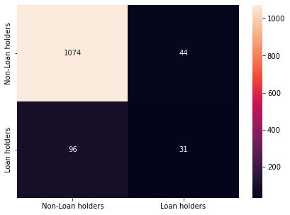

```python
from sklearn import metrics

print("Confusion Matrix")
cm=metrics.confusion_matrix(y_test, predicted_labels, labels=[0, 1])

df_cm = pd.DataFrame(cm, index = [i for i in ["Non-Loan holders","Loan holders"]],
                  columns = [i for i in ["Non-Loan holders","Loan holders"]])
plt.figure(figsize = (7,5))
sns.heatmap(df_cm, annot=True, fmt = 'g')
```

```python
# Tunning Parameters
```

```python
leaf_size = list(range(1,50))
n_neighbors = list(range(1,30))
p=[1,2]
#Convert to dictionary
hyperparameters = dict(leaf_size=leaf_size, n_neighbors=n_neighbors, p=p)
#Create new KNN object
knn_2 = KNeighborsClassifier()
#Use GridSearch
clf = GridSearchCV(knn_2, hyperparameters, cv=10)
#Fit the model
best_model = clf.fit(x,y)
#Print The value of best Hyperparameters
print('Best leaf_size:', best_model.best_estimator_.get_params()['leaf_size'])
print('Best p:', best_model.best_estimator_.get_params()['p'])
print('Best n_neighbors:', best_model.best_estimator_.get_params()['n_neighbors'])
```

```
Best leaf_size: 1
Best p: 1
Best n_neighbors: 28
```

```python
# Training data with SVM
```

```python
from sklearn import svm
```

```python
x_train, x_test, y_train, y_test = train_test_split(x, y, test_size=0.25, random_state=1)
```

```python
clf = svm.SVC(gamma = 0.025, C=3)
```

```python
clf.fit(x_train, y_train)
```

```
SVC(C=3, gamma=0.025)
```

```python
y_pred = clf.predict(x_test)
```

```python
# Metrices
```

```python
print("classification  Matrix:\n",classification_report(y_test,y_pred))
```

```
classification  Matrix:
               precision    recall  f1-score   support

         0.0       0.90      1.00      0.95      1118
         1.0       0.33      0.01      0.02       127

    accuracy                           0.90      1245
   macro avg       0.62      0.50      0.48      1245
weighted avg       0.84      0.90      0.85      1245
```

```python
print('Accuracy on Training data:', clf.fit(x_train, y_train) )
print('Accuracy on Test data:', clf.fit(x_test, y_test) )
```

```
Accuracy on Training data: SVC(C=3, gamma=0.025)
Accuracy on Test data: SVC(C=3, gamma=0.025)
```

```python
# Tunning parameters for SVM with different values of gamma and C
```

```python
clf = svm.SVC(gamma = 0.5, C=1)
clf.fit(x_train, y_train)
y_pred = clf.predict(x_test)
```

```python
print("classification  Matrix:\n",classification_report(y_test,y_pred))
```

[output not shown]

```python
# 2.4 d
```

Maximum accuracy is obtained from Logistic Regression.